# **Linear algebra with Numpy**

Jesús David Petro Ramos - T00065696  
Universidad Tecnológica de Bolívar

Link del repo donde he estado realizando la actividad: [Repo](https://github.com/JesusPetro/Vision-Artificial-2P2025/tree/main/semana%201)

> En este notebook se presentan únicamente las soluciones a los ejercicios del notebook original `00_Linear_algebra_with_Numpy` asignado por el profesor Naufal.

#### *Liberias utilizadas*

```python
import numpy as np
import matplotlib.pyplot as plt
from PIL import Image
```

## **Manipulating matrices**

### **Exercise**

Compute $A ^ 2 - 2 A + 3$ with

$$A = \begin{pmatrix} 1 & -1\\ 2 & 1 \end{pmatrix} $$

**Warning**  
*A<sup>2</sup>* es diferente a *A ** 2*

Según la diapositiva 25 de la presentación *Lec01-linear-algebra-primer*, la operación de **potencia de una matriz** consiste en multiplicar la misma matriz por sí misma tantas veces como lo indique el exponente. Es decir, si tenemos $A^2$, esto equivale a $AA$ , lo cual, en sintaxis de Python usando NumPy, se representa como `A @ A`.

> **Importante**: esta operación solo es válida si la matriz $A$ es **cuadrada** (tiene el mismo número de filas y columnas).

Por otro lado, si escribimos `A ** 2` en Python, lo que hacemos es elevar **cada elemento individual** de la matriz al cuadrado, lo cual **no corresponde a una multiplicación matricial** y por tanto sería un procedimiento **erróneo** si lo que se busca es $A^2$ en el sentido algebraico.

Para visualizar esto de manera gráfica, consideremos una matriz $A$:

$$ A = \begin{pmatrix} w & x \\ y & z \end{pmatrix} $$

Entonces:

$$ A^2 = A @ A = \begin{pmatrix} w & x \\ y & z \end{pmatrix} \begin{pmatrix} w & x \\ y & z \end{pmatrix} $$

$$ A**2 = \begin{pmatrix} w^2 & x^2 \\ y^2 & z^2 \end{pmatrix} $$

> **Nota**: también se puede utilizar el método `numpy.linalg.matrix_power(A, n)` para calcular potencias de matrices de forma correcta.

```python
A = np.array([
    [1, -1],
    [2,  1]
])

result = A@A - 2*A + 3

print("El resultado de A^2 - 2A + 3 es: \n", result)
```

```
El resultado de A^2 - 2A + 3 es:
 [[0 3]
 [3 0]]
```

```python
#Otra forma de calcularlo usando el np.linalg.matrix_power

result2 = np.linalg.matrix_power(A,2) - 2*A + 3
print(result2)
```

```
[[0 3]
 [3 0]]
```

## **Solving Matrix equations**

### **EXERCISE**

Compute the solutions to the matrix equation $Bx=b$ (using the $B$ defined earlier).

$$ B = \begin{pmatrix} 14 & -2 & 12\\ 4 & 4 & 5\\ 5 & 5 & 1 \end{pmatrix} $$

$$ b = \begin{pmatrix} -1\\ 2\\ 1 \end{pmatrix} $$

```python
# Declaramos las matrices B y b
B = np.array([[14, -2, 12],
              [4, 4, 5],
              [5, 5, 1]])

b = np.array([[-1], [2], [1]])

"""
np.linalg.solve resuelve un sistema de ecuaciones lineales de la forma Ax = b,
donde A es la matriz de coeficientes, x es el vector de incógnitas, y b es el vector de términos independientes.
Devuelve la solución x tal que A @ x = b.
"""
x = np.linalg.solve(B, b)

print(f'x = {x}')

# Confirmamos que el resultado sea correcto
# el \033[<numero>m es un código de escape ANSI para cambiar el color del texto en la terminal.
print("\n\n \033[31m--- Verificación de la solución ---\033[0m")
print("B @ x = \n", dot:= B @ x)
print("\nb = \n", b)

# Otra forma de verificar la solución.
# np.allclose verifica si dos arrays son iguales dentro de una tolerancia.
print(f"\n\033[31m¿Bx = b?\033[0m {np.allclose(dot, b)}")
```

```
x = [[-0.25892857]
 [ 0.40178571]
 [ 0.28571429]]


 --- Verificación de la solución ---
B @ x =
 [[-1.]
 [ 2.]
 [ 1.]]

b =
 [[-1]
 [ 2]
 [ 1]]

¿Bx = b? True
```

## Matrix inversion and determinants

### **EXERCISE**

Compute the inverse and determinant of $B$ (defined previously).

$$ B = \begin{pmatrix} 14 & -2 & 12\\ 4 & 4 & 5\\ 5 & 5 & 1 \end{pmatrix} $$

```python
# Calculamos el determinante y la inversa de B

# np.linalg.inv calcula la inversa de una matriz, y np.linalg.det calcula el determinante.
Binv = np.linalg.inv(B)
detB = np.linalg.det(B)

print(f"\n\nEl determinante de B es: {detB}")
print(f"\n\nLa inversa de B es:\n{Binv}")

# Verificamos la solución
print("\n\n\033[31m--- Verificación de la solución: ---\033[0m")

# Multiplicamos la inversa de B por B para comprobar que obtenemos la matriz identidad.
# La matriz identidad es una matriz cuadrada con unos en la diagonal principal y ceros en el resto de las posiciones.
# np.eye(3) crea una matriz identidad de 3x3.
print(f'\n¿Está bien la inversa? \n\n \
\033[31mB^-1 * B = I -> \033[0m \n {(tmp:= Binv @ B)} \n\n \
\033[31mallclose: \033[0m{np.allclose(tmp, np.eye(3))}')
```

```
El determinante de B es: -336.0


La inversa de B es:
[[ 6.25000000e-02 -1.84523810e-01  1.72619048e-01]
 [-6.25000000e-02  1.36904762e-01  6.54761905e-02]
 [-1.09511795e-17  2.38095238e-01 -1.90476190e-01]]


--- Verificación de la solución: ---

¿Está bien la inversa?

 B^-1 * B = I ->
 [[ 1.00000000e+00 -2.77555756e-17  5.55111512e-17]
 [-8.32667268e-17  1.00000000e+00 -1.94289029e-16]
 [-2.77555756e-17  8.32667268e-17  1.00000000e+00]]

 allclose: True
```

## **Rotations**

### **EXERCISE**

Generate a triangle, and apply the same rotation. Observe how the shape changes with different rotation angles.

**Rotation matrix** \begin{bmatrix} \cos(\theta) & -\sin(\theta) \\\\ \sin(\theta) & \cos(\theta) \end{bmatrix}

```python
# Definimos los puntos para el triángulo
points = np.array([
    [0,  1, -1, 0],
    [1, -1, -1, 1]
])
```

```python
# Here is the function
def rotation_matrix(theta):
    theta_rad = np.deg2rad(theta)
    R = np.array([[np.cos(theta_rad), -np.sin(theta_rad)],
                  [np.sin(theta_rad), np.cos(theta_rad)]])
    return R
```

```python
# función para graficar la rotación
# Esta función toma un eje (ax), un ángulo theta, puntos a rotar, un color y una etiqueta opcional.
# Utiliza la matriz de rotación para rotar los puntos y luego los grafica.

def plt_rotation_matrix(ax, theta, points, color = 'b',  label = ''):
    R = rotation_matrix(theta)
    rotated_points = R @ points # tambien se puede usar np.dot(R, points)
    ax.plot(rotated_points[0], rotated_points[1], color=color, label=f'Rotación {theta}°' if not label else f'{label}')
    ax.axis('equal')
    # ax.set_aspect('equal', adjustable='box') -> prueba que posiblemente no termine usando
    ax.grid()
    ax.legend()
```

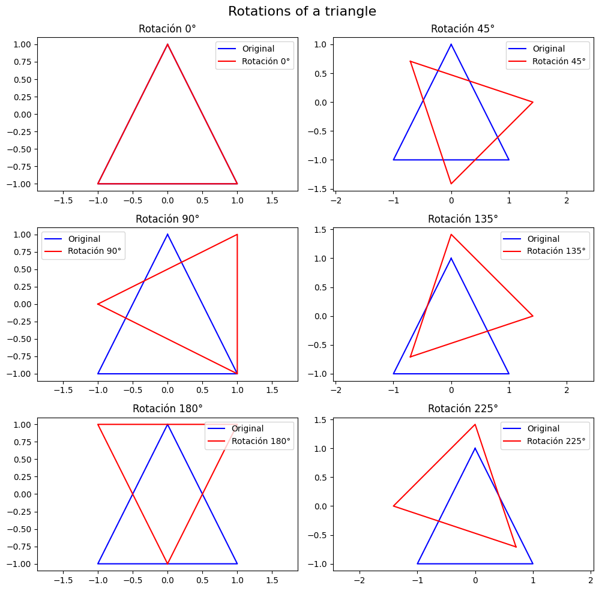

```python
grid = (3, 2) # el tamañode los subplots, se hace de esta manera por si la persona lo quiere modificar, no tenga que modificar todo el código

fig, axes = plt.subplots(*grid, figsize=(10, 10))
total_axes = axes.flat # se aplana el array de ejes para poder iterar sobre ellos fácilmente
rotation_degrees = [45 * _ for _ in range(len(total_axes)) ] # en base a la cantidad de subplots, se generan los grados de rotación


for ax, deg in zip(total_axes, rotation_degrees):
    ax.set_title(f'Rotación {deg}°')

    plt_rotation_matrix(ax, 0, points, color='b', label = 'Original')
    plt_rotation_matrix(ax, deg, points, color='r')


fig.suptitle("Rotations of a triangle", fontsize=16)
plt.tight_layout()
plt.show()
```

## **Image Compression and Reconstruction using SVD**

### **Step1**

```
(5472, 3648, 3)
```

```
(np.float64(-0.5), np.float64(3647.5), np.float64(5471.5), np.float64(-0.5))
```

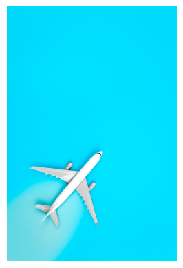

```python
# leemos una imagen y la mostramos
image = Image.open('./img/imagen1.jpg')

print(np.array(image).shape) # rgb (5472, 3648, 3)
plt.imshow(image)
plt.axis('off')  # Oculta los ejes
```

**Info**  
Existen varios métodos para convertir una imagen a escala de grises, pero en este caso, por preferencia personal, se optó por utilizar una de las fórmulas para calcular el *pixel brightness* (nivel de brillo de cada píxel).

```
(5472, 3648)
```

```
(np.float64(-0.5), np.float64(3647.5), np.float64(5471.5), np.float64(-0.5))
```

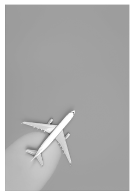

```python
# Hay varias funciones o métodos para aplicar una escala de grises. En este caso usaremos el cálculo
# NTSC/YIQ (0.2989, 0.5870, 0.1140)

def rgb_to_grayscale(image):
    # Convertimos la imagen a un array de numpy
    img_array = np.array(image)

    # Aplicamos la fórmula NTSC/YIQ para convertir a escala de grises
    # 0 -> Red, 1 -> Green, 2 -> Blue ([:, :, <número del canal>])
    gray_image = 0.2989 * img_array[:, :, 0] + 0.5870 * img_array[:, :, 1] + 0.1140 * img_array[:, :, 2]

    # Convertimos el resultado a un formato de imagen
    gray_image = gray_image.astype(np.uint8)

    return gray_image


gray_image = rgb_to_grayscale(image)
print(gray_image.shape)

gray_image = Image.fromarray(gray_image)
plt.imshow(gray_image, cmap='gray') # cmap='gray' aplica el mapa de colores en escala de grises
plt.axis('off')  # Oculta los ejes
```

### **Step2**

Basandonos en las diapositivas, tenemos que el SVD retorna 3 matrices (o da 3 matrices resultantes).

$$U \times \Sigma \times V^{T} = A$$

Si $A$ es una matriz $n \times m$, entonces $U$ es $n \times n$, $\Sigma$ es una matriz diagonal $n \times m$ y $V^{T}$ es $m \times m$.

```python
U, S, Vt = np.linalg.svd(gray_image)
print(f'U.shape = {U.shape}, Σ (S).shape = {S.shape}, Vᵀ.shape = {Vt.shape}')
```

```
U.shape = (5472, 5472), Σ (S).shape = (3648,), Vᵀ.shape = (3648, 3648)
```

### **Step3&4**

```python
def reconstruct_image(u: np.ndarray, s: np.ndarray, vt: np.ndarray, k: int) -> np.ndarray:
    """
    Reconstruye una imagen usando las primeras k componentes de su SVD.

    Parámetros:
    u  -- Matriz U de la SVD
    s  -- Valores singulares (vector 1D)
    vt -- Matriz V^T de la SVD
    k  -- Número de componentes singulares a usar

    Retorna:
    Imagen reconstruida (np.ndarray)
    """
    # Matriz diagonal S_k con los primeros k valores singulares
    S_k = np.diag(s[:k])

    # Usar solo las primeras k columnas/filas de U y V^T
    U_k = u[:, :k]
    VT_k = vt[:k, :]

    # Reconstrucción: U_k * S_k * VT_k
    return np.dot(U_k, np.dot(S_k, VT_k))
```

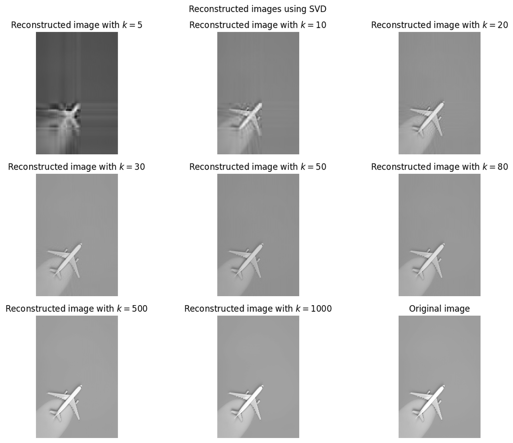

```python
fig, axes = plt.subplots(3, 3, figsize=(16, 9))

k = [5, 10, 20, 30, 50, 80, 500, 1000, 3000]

for k_i, ax in zip(k, axes.flat):
    reconstructed_i = reconstruct_image(U, S, Vt, k_i)
    ax.imshow(reconstructed_i, cmap="gray")
    ax.set_title(f"Reconstructed image with $k={k_i}$")
    ax.axis("off")

axes[2, 2].set_title("Original image")

fig.tight_layout()
fig.suptitle("Reconstructed images using SVD")
fig.tight_layout()

plt.show()
```

Con base en el resultado obtenido, tenemos que a partir de *k* = 20 ya podemos distinguir sin ningún problema la imagen. Con respecto a *k* = 30, se logra un resultado decente y utilizable para visualizar y posiblemente analizar (se puede notar algo de ruido, pero se asumirá que no generará mayor inconveniente en caso de utilizar esa opción de imagen). Si buscamos un resultado casi idéntico (al menos a simple vista) a la imagen original, se puede optar por *k* = 50 o *k* = 80.

<sub>Para la realización de este notebook se tomó en cuenta el material de las diapositivas vistas en clase, el notebook de la actividad, la consulta de la fórmula (actualmente no se cuenta con el enlace utilizado) y una IA para las correcciones de redacción y sugerencias, con el fin de entregar el mejor trabajo posible.</sub>